# matplotlib

### matplotlib vs. matlab: pyplot

- pyplot: a convenient interface to the matplotlib object-oriented plotting library.
- It is modeled closely after Matlab(TM). The majority of plotting commands in pyplot have Matlab(TM) analogs with similar arguments.

### matplotlib settings

```python
import numpy as np
import pandas as pd
import matplotlib
import matplotlib.pyplot as plt
```

```python
matplotlib.__version__
##matplotlib.__file__
import matplotlib
matplotlib.get_data_path()
matplotlib.get_configdir()
##matplotlib.get_cachedir()
```

```
'2.1.1'
```

```
'/anaconda/lib/python3.6/site-packages/matplotlib/mpl-data'
```

```
'/Users/qiangshen/.matplotlib'
```

```python
## file for enviroment variables: matplotlibrc
import os
os.chdir(matplotlib.get_data_path())
os.getcwd()
os.listdir()
! head -13 matplotlibrc
```

```
'/anaconda/lib/python3.6/site-packages/matplotlib/mpl-data'
```

```
['.DS_Store', 'fonts', 'images', 'matplotlibrc', 'sample_data', 'stylelib']
```

```
### MATPLOTLIBRC FORMAT

# This is a sample matplotlib configuration file - you can find a copy
# of it on your system in
# site-packages/matplotlib/mpl-data/matplotlibrc.  If you edit it
# there, please note that it will be overwritten in your next install.
# If you want to keep a permanent local copy that will not be
# overwritten, place it in the following location:
# unix/linux:
#     $HOME/.config/matplotlib/matplotlibrc or
#     $XDG_CONFIG_HOME/matplotlib/matplotlibrc (if $XDG_CONFIG_HOME is set)
# other platforms:
#     $HOME/.matplotlib/matplotlibrc
```

```python
## %matplotlib inline
```

### Fonts: Chinese

- 1. find the location for ttf: `os.chdir(matplotlib.get_data_path())`
- 2. download and copy file msyh.ttf to this directory
- 3. in **matplotlibrc** file under **mpl-data**(using `matplotlib.get_data_path()` to get the directory): uncomment line 199: font.family: sans-serif and add Microsoft YaHei after font.sans-serif in line 211
- 4. get the directory for fontList.cache with `matplotlib.get_cachedir()` and remove *.cache file(`rm -rf ~/.matplotlib/*`.cache, **be careful!!! a dangerous command!!!**).

```python
from matplotlib.font_manager import FontManager
import subprocess
fm = FontManager()
mat_fonts = set(f.name for f in fm.ttflist)
##mat_fonts
#matplotlib.__file__
#ttf=os.listdir('/anaconda/lib/python3.6/site-packages/matplotlib/mpl-data/fonts/ttf')
#ttf[0:10]
#os.listdir(matplotlib.get_cachedir())
```

```python
plt.rcParams.get('font.sans-serif')
```

```
['Microsoft YaHei',
 'DejaVu Sans',
 'Bitstream Vera Sans',
 'Lucida Grande',
 'Verdana',
 'Geneva',
 'Lucid',
 'Arial',
 'Helvetica',
 'Avant Garde',
 'sans-serif']
```

### simple figure

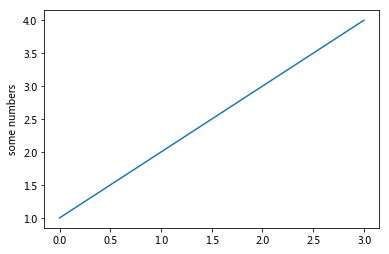

```python
plt.plot([1,2,3,4])
plt.ylabel('some numbers')
plt.show();
```

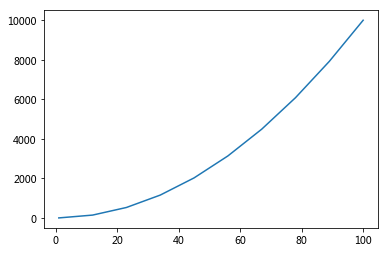

```python
plt.plot(np.linspace(1,100,10),np.linspace(1,100,10)**2)
## plt.axis([-5, 110, -1000, 11000])
plt.show();
```

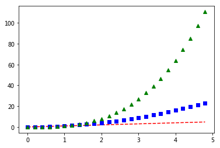

```python
# evenly sampled time at 200ms intervals
t = np.arange(0., 5., 0.2)
# red dashes, blue squares and green triangles
plt.plot(t, t, 'r--', t, t**2, 'bs', t, t**3, 'g^')
plt.show();
```

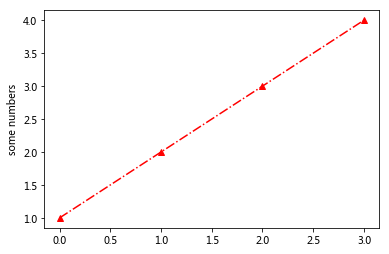

```python
plt.plot([1,2,3,4],'^-.r')
plt.ylabel('some numbers')
plt.show();
```

### Controlling line properties

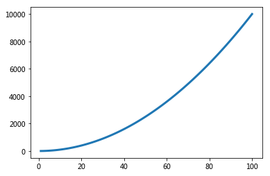

```python
##1. keyword args
x = np.linspace(1,100,100)
y = np.linspace(1,100,100)**2
plt.plot(x, y, linewidth=3.0)
plt.show();
```

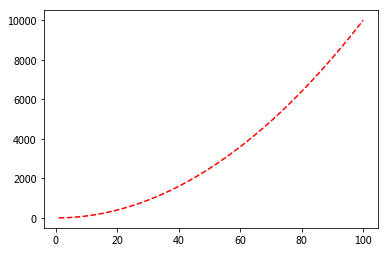

```python
##setter methods
line, = plt.plot(x, y, 'r--')
plt.show()
```

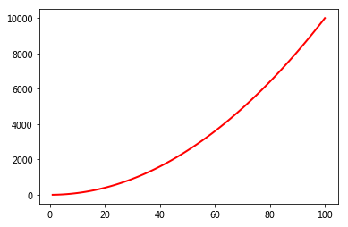

```python
##MATLAB-style command
lines = plt.plot(x,y)
# use keyword args
plt.setp(lines, color='r', linewidth=2.0)
# or MATLAB style string value pairs
plt.setp(lines, 'color', 'r', 'linewidth', 2.0)
plt.show();
```

### Figures

[figure not shown]

### Line styles

[figure not shown]

### Markers

[figure not shown]

### Colormaps: category10 (Tableau:d3.scale.category10())

[figure not shown]

### basic plot: Using defaults

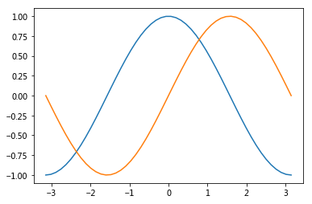

```python
X = np.linspace(-np.pi, np.pi, 50)
C,S = np.cos(X), np.sin(X);
plt.plot(X,C)
plt.plot(X,S)
plt.show();
```

### Get default parameters

```python
import matplotlib.pyplot as plt
##plt.rcParams # to examine all values
plt.rcParams.get('figure.figsize')
plt.rcParams.get('figure.dpi')
##plt.rcParams.get('figure.facecolor')
##plt.rcParams.get('figure.edgecolor')
##plt.rcParams.get('figure.frameon')
```

```
[6.0, 4.0]
```

```
72.0
```

### Instantiating default: parameters

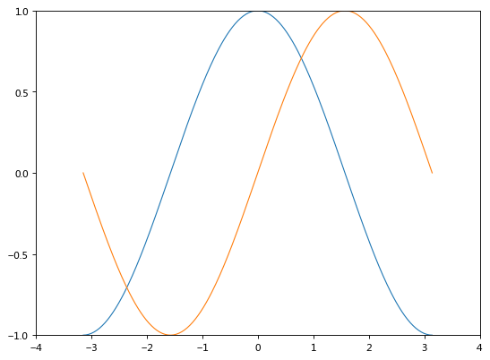

```python
# Create a new figure of size 8x6 points, using 80 dots per inch
plt.figure(figsize=(8,6), dpi=80)

# Create a new subplot from a grid of 1x1
plt.subplot(111)

X = np.linspace(-np.pi, np.pi, 256,endpoint=True)
C,S = np.cos(X), np.sin(X)

# Plot cosine using blue color with a continuous line of width 1 (pixels)
plt.plot(X, C, color="C0", linewidth=1.0, linestyle="-")

# Plot sine using green color with a continuous line of width 1 (pixels)
plt.plot(X, S, color="C1", linewidth=1.0, linestyle="-")

# Set x limits
plt.xlim(-4.0,4.0)

# Set x ticks
plt.xticks(np.linspace(-4,4,9,endpoint=True))

# Set y limits
plt.ylim(-1.0,1.0)

# Set y ticks
plt.yticks(np.linspace(-1,1,5,endpoint=True))

# Save figure using 72 dots per inch
plt.savefig("figures/exercice.pdf",dpi=300)

# Show result on screen
plt.show();
```

### Changing colors and line widths

- cosine in blue and the sine in red
- a slightly thicker line for both of them
- the figure size to make it more horizontal.

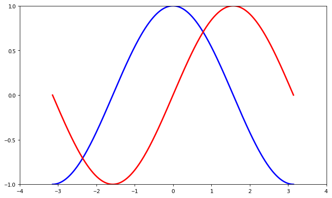

```python
# Create a new figure of size 8x6 points, using 80 dots per inch
plt.figure(figsize=(10,6), dpi=80)

# Create a new subplot from a grid of 1x1
plt.subplot(111)

X = np.linspace(-np.pi, np.pi, 256,endpoint=True)
C,S = np.cos(X), np.sin(X)

# Plot cosine using blue color with a continuous line of width 1 (pixels)
plt.plot(X, C, color="blue", linewidth=2.5, linestyle="-")

# Plot sine using green color with a continuous line of width 1 (pixels)
plt.plot(X, S, color="red", linewidth=2.5, linestyle="-")

# Set x limits
plt.xlim(-4.0,4.0)

# Set x ticks
plt.xticks(np.linspace(-4,4,9,endpoint=True))

# Set y limits
plt.ylim(-1.0,1.0)

# Set y ticks
plt.yticks(np.linspace(-1,1,5,endpoint=True))

# Save figure using 72 dots per inch
plt.savefig("figures/exercice.pdf",dpi=300)

# Show result on screen
plt.show();
```

## Setting limits

- limits of the figure are a bit too tight
- make some space in order to clearly see all data points.

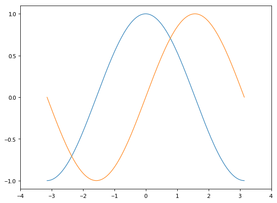

```python
# Create a new figure of size 8x6 points, using 80 dots per inch
plt.figure(figsize=(8,6), dpi=80);

# Create a new subplot from a grid of 1x1
plt.subplot(111);

X = np.linspace(-np.pi, np.pi, 256,endpoint=True);
C,S = np.cos(X), np.sin(X);

# Plot cosine using blue color with a continuous line of width 1 (pixels)
plt.plot(X, C, color="C0", linewidth=1.0, linestyle="-");

# Plot sine using green color with a continuous line of width 1 (pixels)
plt.plot(X, S, color="C1", linewidth=1.0, linestyle="-");

# Set x limits
#plt.xlim(-4.0,4.0)

# Set y limits
#plt.ylim(-1,1)

plt.xlim(X.min()*1.1, X.max()*1.1)
plt.ylim(C.min()*1.1, C.max()*1.1)

# Set x ticks
plt.xticks(np.linspace(-4,4,9,endpoint=True))

# Set y ticks
plt.yticks(np.linspace(-1,1,5,endpoint=True))


# Show result on screen
plt.show();
```

### Setting ticks: x axis, y axis

- Current ticks are not ideal because they do not show the interesting values (+/-π,+/-π/2) for sine and cosine. We'll change them such that they show only these values.

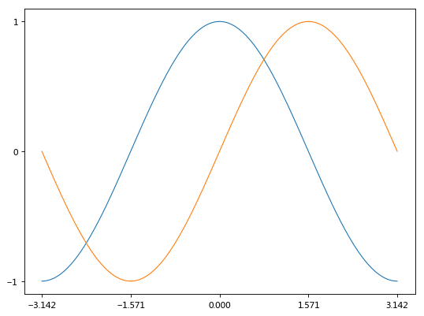

```python
# Create a new figure of size 8x6 points, using 80 dots per inch
plt.figure(figsize=(8,6), dpi=80);

# Create a new subplot from a grid of 1x1
plt.subplot(111);

X = np.linspace(-np.pi, np.pi, 256,endpoint=True);
C,S = np.cos(X), np.sin(X);

# Plot cosine using blue color with a continuous line of width 1 (pixels)
plt.plot(X, C, color="C0", linewidth=1.0, linestyle="-");

# Plot sine using green color with a continuous line of width 1 (pixels)
plt.plot(X, S, color="C1", linewidth=1.0, linestyle="-");


# Set x limits
plt.xlim(-4.0,4.0)

# Set x ticks
#plt.xticks(np.linspace(-4,4,9,endpoint=True))

# Set y limits
#plt.ylim(-1,1)

plt.xlim(X.min()*1.1, X.max()*1.1)
plt.ylim(C.min()*1.1, C.max()*1.1)

plt.xticks( [-np.pi, -np.pi/2, 0, np.pi/2, np.pi])
plt.yticks([-1, 0, +1])

# Set y ticks
#plt.yticks(np.linspace(-1,1,5,endpoint=True))

# Show result on screen
plt.show();
```

### Setting tick labels: Latex

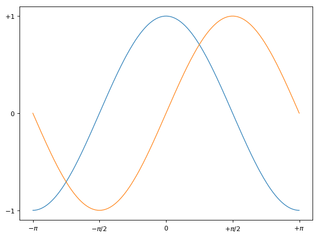

```python
# Create a new figure of size 8x6 points, using 80 dots per inch
plt.figure(figsize=(8,6), dpi=80);

# Create a new subplot from a grid of 1x1
plt.subplot(111);

X = np.linspace(-np.pi, np.pi, 256,endpoint=True);
C,S = np.cos(X), np.sin(X);

# Plot cosine using blue color with a continuous line of width 1 (pixels)
plt.plot(X, C, color="C0", linewidth=1.0, linestyle="-");

# Plot sine using green color with a continuous line of width 1 (pixels)
plt.plot(X, S, color="C1", linewidth=1.0, linestyle="-");

# Set x limits
plt.xlim(-4.0,4.0);

# Set x ticks
##plt.xticks(np.linspace(-4,4,9,endpoint=True))

# Set y limits
plt.ylim(-1,1);

plt.xlim(X.min()*1.1, X.max()*1.1);
plt.ylim(C.min()*1.1, C.max()*1.1);


plt.xticks([-np.pi, -np.pi/2, 0, np.pi/2, np.pi],
       [r'$-\pi$', r'$-\pi/2$', r'$0$', r'$+\pi/2$', r'$+\pi$'])

plt.yticks([-1, 0, +1],
       [r'$-1$', r'$0$', r'$+1$'])

# Set y ticks
##plt.yticks(np.linspace(-1,1,5,endpoint=True))

# Save figure using 72 dots per inch
plt.savefig("figures/exercice.pdf",dpi=300)

# Show result on screen
plt.show();
```

### Moving spines

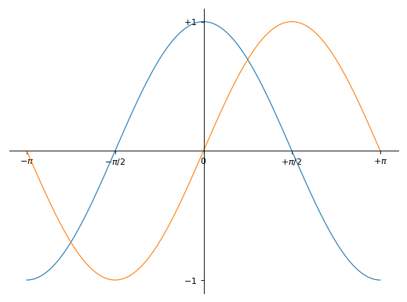

```python
# Create a new figure of size 8x6 points, using 80 dots per inch
plt.figure(figsize=(8,6), dpi=80);

# Create a new subplot from a grid of 1x1
plt.subplot(111);

X = np.linspace(-np.pi, np.pi, 256,endpoint=True);
C,S = np.cos(X), np.sin(X);

# Plot cosine using blue color with a continuous line of width 1 (pixels)
plt.plot(X, C, color="C0", linewidth=1.0, linestyle="-");

# Plot sine using green color with a continuous line of width 1 (pixels)
plt.plot(X, S, color="C1", linewidth=1.0, linestyle="-");


ax = plt.gca();
ax.spines['right'].set_color('none');
ax.spines['top'].set_color('none');
ax.xaxis.set_ticks_position('bottom');
ax.spines['bottom'].set_position(('data',0));
ax.yaxis.set_ticks_position('left');
ax.spines['left'].set_position(('data',0));


# Set x limits
#plt.xlim(-4.0,4.0)

# Set x ticks
##plt.xticks(np.linspace(-4,4,9,endpoint=True))

# Set y limits
#plt.ylim(-1,1)

plt.xlim(X.min()*1.1, X.max()*1.1)
plt.ylim(C.min()*1.1, C.max()*1.1)

plt.xticks([-np.pi, -np.pi/2, 0, np.pi/2, np.pi],
       [r'$-\pi$', r'$-\pi/2$', r'$0$', r'$+\pi/2$', r'$+\pi$'])

plt.yticks([-1, +1],
       [r'$-1$', r'$+1$'])

# Set y ticks
##plt.yticks(np.linspace(-1,1,5,endpoint=True))
# Show result on screen
plt.show();
```

### adding a legend

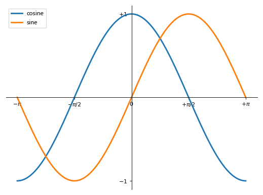

```python
import numpy as np
import matplotlib.pyplot as plt
# Create a new figure of size 8x6 points, using 80 dots per inch
plt.figure(figsize=(8,6), dpi=80);

# Create a new subplot from a grid of 1x1
plt.subplot(111);

X = np.linspace(-np.pi, np.pi, 256,endpoint=True);
C,S = np.cos(X), np.sin(X);

# Plot cosine using blue color with a continuous line of width 1 (pixels)
plt.plot(X, C, color="C0", linewidth=2.5, linestyle="-",label='cosine');

# Plot sine using green color with a continuous line of width 1 (pixels)
plt.plot(X, S, color="C1", linewidth=2.5, linestyle="-",label='sine');

# Set x limits
plt.xlim(-4.0,4.0);

# Set x ticks
##plt.xticks(np.linspace(-4,4,9,endpoint=True))

# Set y limits
plt.ylim(-1,1);

plt.xlim(X.min()*1.1, X.max()*1.1);
plt.ylim(C.min()*1.1, C.max()*1.1);
plt.xticks([-np.pi, -np.pi/2, 0, np.pi/2, np.pi],
       [r'$-\pi$', r'$-\pi/2$', r'$0$', r'$+\pi/2$', r'$+\pi$']);

plt.yticks([-1, +1],
       [r'$-1$', r'$+1$']);

# Set y ticks
##plt.yticks(np.linspace(-1,1,5,endpoint=True))


ax = plt.gca();
ax.spines['right'].set_color('none');
ax.spines['top'].set_color('none');
ax.xaxis.set_ticks_position('bottom');
ax.spines['bottom'].set_position(('data',0));
ax.yaxis.set_ticks_position('left');
ax.spines['left'].set_position(('data',0));

plt.legend(loc='upper left', frameon=True)

# Show result on screen
plt.show();
```

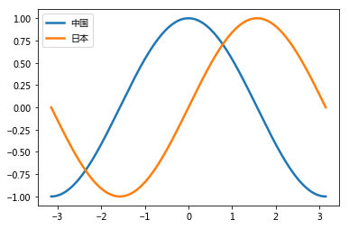

```python
##plt.style.use('chinese_support') ##http://blog.hszofficial.site/TutorialForPythonDataAnalysis/matplotlib/matplotlib_config/matplotlib_config.html
##plt.rcParams['font.sans-serif']=['SimHei'] or Microsoft YaHei,based on the ttf file ##https://www.zhihu.com/question/25404709
plt.plot(X, C, color="C0", linewidth=2.5, linestyle="-", label="中国")###1f77b4
plt.plot(X, S, color="C1",  linewidth=2.5, linestyle="-", label="日本")####ff7f0e

plt.legend(loc='upper left', frameon=True)
plt.show();
```

### Annotate some points

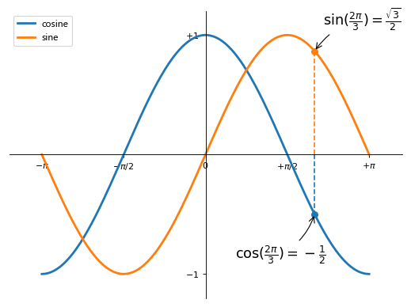

```python
#!/usr/bin/env python3
# -*- coding: utf-8 -*-
"""
Created on Sat Dec 16 12:23:04 2017

@author: qiangshen
"""
# Imports
import numpy as np
import matplotlib.pyplot as plt

# Create a new figure of size 8x6 points, using 100 dots per inch
plt.figure(figsize=(8,6), dpi=80)

# Create a new subplot from a grid of 1x1
plt.subplot(111)

X = np.linspace(-np.pi, np.pi, 256,endpoint=True)
C,S = np.cos(X), np.sin(X)

# Plot cosine using blue color with a continuous line of width 1 (pixels)
plt.plot(X, C, color="#1f77b4", linewidth=2.5, linestyle="-",label="cosine")

# Plot sine using green color with a continuous line of width 1 (pixels)
plt.plot(X, S, color="#ff7f0e", linewidth=2.5, linestyle="-",label="sine")

# Set x limits
plt.xlim(X.min()*1.2,X.max()*1.2)
##plt.xlim(-4.0,4.0)

# Set x ticks

plt.xticks([-np.pi,-np.pi/2,0,np.pi/2,np.pi],[r'$-\pi$', r'$-\pi/2$', r'$0$', r'$+\pi/2$', r'$+\pi$'])
##np.linspace(-4,4,9,endpoint=True)
# Set y limits
plt.ylim(S.min()*1.2,S.max()*1.2)
#plt.ylim(-1.2,1.2)

# Set y ticks
plt.yticks([-1,0,1],[r'$-1$', r'', r'$+1$'])
np.linspace(-1,1,5,endpoint=True)
# Save figure using 72 dots per inch
#plt.savefig("figures/exercice_2.png",dpi=72)

ax = plt.gca()
ax.spines['right'].set_color('none')
ax.spines['top'].set_color('none')

ax.xaxis.set_ticks_position('bottom')
ax.spines['bottom'].set_position(('data',0))
ax.yaxis.set_ticks_position('left')
ax.spines['left'].set_position(('data',0))

plt.legend(loc='upper left', frameon=True);
# Show result on screen


t = 2*np.pi/3
plt.plot([t,t],[0,np.cos(t)], color ='#1f77b4', linewidth=1.5, linestyle="--")
plt.scatter([t,],[np.cos(t),], 50, color ='#1f77b4')

plt.annotate(r'$\sin(\frac{2\pi}{3})=\frac{\sqrt{3}}{2}$',
             xy=(t, np.sin(t)), xycoords='data',
             xytext=(+10, +30), textcoords='offset points', fontsize=16,
             arrowprops=dict(arrowstyle="->", connectionstyle="arc3,rad=.2"))

plt.plot([t,t],[0,np.sin(t)], color ='#ff7f0e', linewidth=1.5, linestyle="--")
plt.scatter([t,],[np.sin(t),], 50, color ='#ff7f0e')

plt.annotate(r'$\cos(\frac{2\pi}{3})=-\frac{1}{2}$',
             xy=(t, np.cos(t)), xycoords='data',
             xytext=(-90, -50), textcoords='offset points', fontsize=16,
             arrowprops=dict(arrowstyle="->", connectionstyle="arc3,rad=.2"))


plt.show();
```

### Style

```python
### mplstyle
mplstyle=os.listdir('/anaconda/lib/python3.6/site-packages/matplotlib/mpl-data/stylelib')
mplstyle[0:10]
```

```
['_classic_test.mplstyle',
 'animation_support.mplstyle',
 'bmh.mplstyle',
 'chinese_support.mplstyle',
 'classic.mplstyle',
 'dark_background.mplstyle',
 'fast.mplstyle',
 'fivethirtyeight.mplstyle',
 'ggplot.mplstyle',
 'grayscale.mplstyle']
```

```python
import matplotlib.style
import matplotlib as mpl
##mpl.style.use('classic')
plt.style.use('ggplot')
print(plt.style.available)
## https://tonysyu.github.io/raw_content/matplotlib-style-gallery/gallery.html
## http://www.futurile.net/2016/02/27/matplotlib-beautiful-plots-with-style/
```

[output not shown]

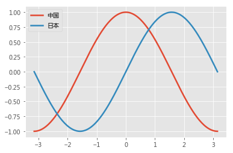

```python
##plt.style.use('chinese_support') ##http://blog.hszofficial.site/TutorialForPythonDataAnalysis/matplotlib/matplotlib_config/matplotlib_config.html
##plt.rcParams['font.sans-serif']=['SimHei'] or Microsoft YaHei,based on the ttf file ##https://www.zhihu.com/question/25404709
plt.plot(X, C, color="C0", linewidth=2.5, linestyle="-", label="中国")###1f77b4
plt.plot(X, S, color="C1",  linewidth=2.5, linestyle="-", label="日本")####ff7f0e

plt.legend(loc='upper left', frameon=True)
plt.show();
```